# 23048657 Bimarsha Raut

#### Import the dataset

```python
import pandas as pd # import the pandas library
```

```python
# import the csv file
df = pd.read_csv('Customer Service_Requests_from_2010_to_Present.csv', low_memory = False)
```

```python
# Display the first 7 rows of the DataFrame 'df'
df.head(7)
```

|  | Unique Key | Created Date | Closed Date | Agency | Agency Name | Complaint Type | Descriptor | Location Type | Incident Zip | Incident Address | ... | Bridge Highway Name | Bridge Highway Direction | Road Ramp | Bridge Highway Segment | Garage Lot Name | Ferry Direction | Ferry Terminal Name | Latitude | Longitude | Location |
| --- | --- | --- | --- | --- | --- | --- | --- | --- | --- | --- | --- | --- | --- | --- | --- | --- | --- | --- | --- | --- | --- |
| 0 | 32310363 | 12/31/2015 11:59:45 PM | 01-01-16 0:55 | NYPD | New York City Police Department | Noise - Street/Sidewalk | Loud Music/Party | Street/Sidewalk | 10034.0 | 71 VERMILYEA AVENUE | ... | NaN | NaN | NaN | NaN | NaN | NaN | NaN | 40.865682 | -73.923501 | (40.86568153633767, -73.92350095571744) |
| 1 | 32309934 | 12/31/2015 11:59:44 PM | 01-01-16 1:26 | NYPD | New York City Police Department | Blocked Driveway | No Access | Street/Sidewalk | 11105.0 | 27-07 23 AVENUE | ... | NaN | NaN | NaN | NaN | NaN | NaN | NaN | 40.775945 | -73.915094 | (40.775945312321085, -73.91509393898605) |
| 2 | 32309159 | 12/31/2015 11:59:29 PM | 01-01-16 4:51 | NYPD | New York City Police Department | Blocked Driveway | No Access | Street/Sidewalk | 10458.0 | 2897 VALENTINE AVENUE | ... | NaN | NaN | NaN | NaN | NaN | NaN | NaN | 40.870325 | -73.888525 | (40.870324522111424, -73.88852464418646) |
| 3 | 32305098 | 12/31/2015 11:57:46 PM | 01-01-16 7:43 | NYPD | New York City Police Department | Illegal Parking | Commercial Overnight Parking | Street/Sidewalk | 10461.0 | 2940 BAISLEY AVENUE | ... | NaN | NaN | NaN | NaN | NaN | NaN | NaN | 40.835994 | -73.828379 | (40.83599404683083, -73.82837939584206) |
| 4 | 32306529 | 12/31/2015 11:56:58 PM | 01-01-16 3:24 | NYPD | New York City Police Department | Illegal Parking | Blocked Sidewalk | Street/Sidewalk | 11373.0 | 87-14 57 ROAD | ... | NaN | NaN | NaN | NaN | NaN | NaN | NaN | 40.733060 | -73.874170 | (40.733059618956815, -73.87416975810375) |
| 5 | 32306554 | 12/31/2015 11:56:30 PM | 01-01-16 1:50 | NYPD | New York City Police Department | Illegal Parking | Posted Parking Sign Violation | Street/Sidewalk | 11215.0 | 260 21 STREET | ... | NaN | NaN | NaN | NaN | NaN | NaN | NaN | 40.660823 | -73.992568 | (40.66082272389114, -73.99256786342693) |
| 6 | 32306559 | 12/31/2015 11:55:32 PM | 01-01-16 1:53 | NYPD | New York City Police Department | Illegal Parking | Blocked Hydrant | Street/Sidewalk | 10032.0 | 524 WEST 169 STREET | ... | NaN | NaN | NaN | NaN | NaN | NaN | NaN | 40.840848 | -73.937375 | (40.840847591440415, -73.9373750864581) |

7 rows × 53 columns

#### 2. Provide your insight on the information and details that the provided dataset carries.

```python
# Displays a concise summary of the DataFrame, including column names, non-null counts, and data types
df.info()
```

```
<class 'pandas.core.frame.DataFrame'>
RangeIndex: 300698 entries, 0 to 300697
Data columns (total 53 columns):
 #   Column                          Non-Null Count   Dtype
---  ------                          --------------   -----
 0   Unique Key                      300698 non-null  int64
 1   Created Date                    300698 non-null  object
 2   Closed Date                     298534 non-null  object
 3   Agency                          300698 non-null  object
 4   Agency Name                     300698 non-null  object
 5   Complaint Type                  300698 non-null  object
 6   Descriptor                      294784 non-null  object
 7   Location Type                   300567 non-null  object
 8   Incident Zip                    298083 non-null  float64
 9   Incident Address                256288 non-null  object
```

[output cut: 45 more lines]

#### 3. Convert the columns "Created Date" and "Closed Date" to datetime datatype and create a new column "Request_Closing_Time" as the time elapsed between request creation and request closing.

```python
# Convert the 'Created Date' column to datetime format (from object/string)
df['Created Date'] = df['Created Date'].astype('datetime64[ns]')

# Convert the 'Closed Date' column to datetime format (from object/string)
df['Closed Date'] = df['Closed Date'].astype('datetime64[ns]')
```

```python
# Displays a concise summary of the DataFrame
df.info()
```

```
<class 'pandas.core.frame.DataFrame'>
RangeIndex: 300698 entries, 0 to 300697
Data columns (total 53 columns):
 #   Column                          Non-Null Count   Dtype
---  ------                          --------------   -----
 0   Unique Key                      300698 non-null  int64
 1   Created Date                    300698 non-null  datetime64[ns]
 2   Closed Date                     298534 non-null  datetime64[ns]
 3   Agency                          300698 non-null  object
 4   Agency Name                     300698 non-null  object
 5   Complaint Type                  300698 non-null  object
 6   Descriptor                      294784 non-null  object
 7   Location Type                   300567 non-null  object
 8   Incident Zip                    298083 non-null  float64
 9   Incident Address                256288 non-null  object
```

[output cut: 45 more lines]

```python
df.head(7)
```

|  | Unique Key | Created Date | Closed Date | Agency | Agency Name | Complaint Type | Descriptor | Location Type | Incident Zip | Incident Address | ... | Bridge Highway Name | Bridge Highway Direction | Road Ramp | Bridge Highway Segment | Garage Lot Name | Ferry Direction | Ferry Terminal Name | Latitude | Longitude | Location |
| --- | --- | --- | --- | --- | --- | --- | --- | --- | --- | --- | --- | --- | --- | --- | --- | --- | --- | --- | --- | --- | --- |
| 0 | 32310363 | 2015-12-31 23:59:45 | 2016-01-01 00:55:00 | NYPD | New York City Police Department | Noise - Street/Sidewalk | Loud Music/Party | Street/Sidewalk | 10034.0 | 71 VERMILYEA AVENUE | ... | NaN | NaN | NaN | NaN | NaN | NaN | NaN | 40.865682 | -73.923501 | (40.86568153633767, -73.92350095571744) |
| 1 | 32309934 | 2015-12-31 23:59:44 | 2016-01-01 01:26:00 | NYPD | New York City Police Department | Blocked Driveway | No Access | Street/Sidewalk | 11105.0 | 27-07 23 AVENUE | ... | NaN | NaN | NaN | NaN | NaN | NaN | NaN | 40.775945 | -73.915094 | (40.775945312321085, -73.91509393898605) |
| 2 | 32309159 | 2015-12-31 23:59:29 | 2016-01-01 04:51:00 | NYPD | New York City Police Department | Blocked Driveway | No Access | Street/Sidewalk | 10458.0 | 2897 VALENTINE AVENUE | ... | NaN | NaN | NaN | NaN | NaN | NaN | NaN | 40.870325 | -73.888525 | (40.870324522111424, -73.88852464418646) |
| 3 | 32305098 | 2015-12-31 23:57:46 | 2016-01-01 07:43:00 | NYPD | New York City Police Department | Illegal Parking | Commercial Overnight Parking | Street/Sidewalk | 10461.0 | 2940 BAISLEY AVENUE | ... | NaN | NaN | NaN | NaN | NaN | NaN | NaN | 40.835994 | -73.828379 | (40.83599404683083, -73.82837939584206) |
| 4 | 32306529 | 2015-12-31 23:56:58 | 2016-01-01 03:24:00 | NYPD | New York City Police Department | Illegal Parking | Blocked Sidewalk | Street/Sidewalk | 11373.0 | 87-14 57 ROAD | ... | NaN | NaN | NaN | NaN | NaN | NaN | NaN | 40.733060 | -73.874170 | (40.733059618956815, -73.87416975810375) |
| 5 | 32306554 | 2015-12-31 23:56:30 | 2016-01-01 01:50:00 | NYPD | New York City Police Department | Illegal Parking | Posted Parking Sign Violation | Street/Sidewalk | 11215.0 | 260 21 STREET | ... | NaN | NaN | NaN | NaN | NaN | NaN | NaN | 40.660823 | -73.992568 | (40.66082272389114, -73.99256786342693) |
| 6 | 32306559 | 2015-12-31 23:55:32 | 2016-01-01 01:53:00 | NYPD | New York City Police Department | Illegal Parking | Blocked Hydrant | Street/Sidewalk | 10032.0 | 524 WEST 169 STREET | ... | NaN | NaN | NaN | NaN | NaN | NaN | NaN | 40.840848 | -73.937375 | (40.840847591440415, -73.9373750864581) |

7 rows × 53 columns

```python
# Create a new column 'Request_Closing_Time' that calculates how long it took to close each request
df['Request_Closing_Time'] = df['Closed Date'] - df['Created Date']
```

```python
df.head()
```

|  | Unique Key | Created Date | Closed Date | Agency | Agency Name | Complaint Type | Descriptor | Location Type | Incident Zip | Incident Address | ... | Bridge Highway Direction | Road Ramp | Bridge Highway Segment | Garage Lot Name | Ferry Direction | Ferry Terminal Name | Latitude | Longitude | Location | Request_Closing_Time |
| --- | --- | --- | --- | --- | --- | --- | --- | --- | --- | --- | --- | --- | --- | --- | --- | --- | --- | --- | --- | --- | --- |
| 0 | 32310363 | 2015-12-31 23:59:45 | 2016-01-01 00:55:00 | NYPD | New York City Police Department | Noise - Street/Sidewalk | Loud Music/Party | Street/Sidewalk | 10034.0 | 71 VERMILYEA AVENUE | ... | NaN | NaN | NaN | NaN | NaN | NaN | 40.865682 | -73.923501 | (40.86568153633767, -73.92350095571744) | 0 days 00:55:15 |
| 1 | 32309934 | 2015-12-31 23:59:44 | 2016-01-01 01:26:00 | NYPD | New York City Police Department | Blocked Driveway | No Access | Street/Sidewalk | 11105.0 | 27-07 23 AVENUE | ... | NaN | NaN | NaN | NaN | NaN | NaN | 40.775945 | -73.915094 | (40.775945312321085, -73.91509393898605) | 0 days 01:26:16 |
| 2 | 32309159 | 2015-12-31 23:59:29 | 2016-01-01 04:51:00 | NYPD | New York City Police Department | Blocked Driveway | No Access | Street/Sidewalk | 10458.0 | 2897 VALENTINE AVENUE | ... | NaN | NaN | NaN | NaN | NaN | NaN | 40.870325 | -73.888525 | (40.870324522111424, -73.88852464418646) | 0 days 04:51:31 |
| 3 | 32305098 | 2015-12-31 23:57:46 | 2016-01-01 07:43:00 | NYPD | New York City Police Department | Illegal Parking | Commercial Overnight Parking | Street/Sidewalk | 10461.0 | 2940 BAISLEY AVENUE | ... | NaN | NaN | NaN | NaN | NaN | NaN | 40.835994 | -73.828379 | (40.83599404683083, -73.82837939584206) | 0 days 07:45:14 |
| 4 | 32306529 | 2015-12-31 23:56:58 | 2016-01-01 03:24:00 | NYPD | New York City Police Department | Illegal Parking | Blocked Sidewalk | Street/Sidewalk | 11373.0 | 87-14 57 ROAD | ... | NaN | NaN | NaN | NaN | NaN | NaN | 40.733060 | -73.874170 | (40.733059618956815, -73.87416975810375) | 0 days 03:27:02 |

5 rows × 54 columns

```python
df.info()
```

```
<class 'pandas.core.frame.DataFrame'>
RangeIndex: 300698 entries, 0 to 300697
Data columns (total 54 columns):
 #   Column                          Non-Null Count   Dtype
---  ------                          --------------   -----
 0   Unique Key                      300698 non-null  int64
 1   Created Date                    300698 non-null  datetime64[ns]
 2   Closed Date                     298534 non-null  datetime64[ns]
 3   Agency                          300698 non-null  object
 4   Agency Name                     300698 non-null  object
 5   Complaint Type                  300698 non-null  object
 6   Descriptor                      294784 non-null  object
 7   Location Type                   300567 non-null  object
 8   Incident Zip                    298083 non-null  float64
 9   Incident Address                256288 non-null  object
```

[output cut: 46 more lines]

#### 4. Write a python program to drop irrelevant Columns which are listed below.

```python
# make a list of columns to delete
columns = ['Agency Name','Incident Address','Street Name',
            'Cross Street 1','Cross Street 2','Intersection Street 1',
            'Intersection Street 2','Address Type','Park Facility Name',
            'Park Borough','School Name', 'School Number','School Region',
            'School Code','School Phone Number','School Address',
            'School City', 'School State','School Zip','School Not Found',
            'School or Citywide Complaint',
            'Vehicle Type', 'Taxi Company Borough','Bridge Highway Name',
            'Bridge Highway Direction',
            'Road Ramp','Bridge Highway Segment','Garage Lot Name',
            'Ferry Direction','Ferry Terminal Name',
            'Landmark','X Coordinate (State Plane)','Y Coordinate (State Plane)',
            'Due Date', 'Resolution Action Updated Date',
            'Community Board','Facility Type','Location', 'Taxi Pick Up Location']
```

```python
# drop the colunns
df = df.drop(columns = columns)
```

```python
# Displays a concise summary of the DataFrame
df.info()
```

```
<class 'pandas.core.frame.DataFrame'>
RangeIndex: 300698 entries, 0 to 300697
Data columns (total 15 columns):
 #   Column                  Non-Null Count   Dtype
---  ------                  --------------   -----
 0   Unique Key              300698 non-null  int64
 1   Created Date            300698 non-null  datetime64[ns]
 2   Closed Date             298534 non-null  datetime64[ns]
 3   Agency                  300698 non-null  object
 4   Complaint Type          300698 non-null  object
 5   Descriptor              294784 non-null  object
 6   Location Type           300567 non-null  object
 7   Incident Zip            298083 non-null  float64
 8   City                    298084 non-null  object
 9   Status                  300698 non-null  object
 10  Resolution Description  300698 non-null  object
 11  Borough                 300698 non-null  object
 12  Latitude                297158 non-null  float64
 13  Longitude               297158 non-null  float64
 14  Request_Closing_Time    298534 non-null  timedelta64[ns]
dtypes: datetime64[ns](2), float64(3), int64(1), object(8), timedelta64[ns](1)
memory usage: 34.4+ MB
```

#### 5. Write a python program to remove the NaN missing values from updated dataframe.

```python
# Drop all rows that contain any missing (NaN) values from the DataFrame
df.dropna(axis = 0, how = 'any', inplace = True)
```

```python
#After the removal of NaN Values
df.info()
```

```
<class 'pandas.core.frame.DataFrame'>
Index: 291107 entries, 0 to 300697
Data columns (total 15 columns):
 #   Column                  Non-Null Count   Dtype
---  ------                  --------------   -----
 0   Unique Key              291107 non-null  int64
 1   Created Date            291107 non-null  datetime64[ns]
 2   Closed Date             291107 non-null  datetime64[ns]
 3   Agency                  291107 non-null  object
 4   Complaint Type          291107 non-null  object
 5   Descriptor              291107 non-null  object
 6   Location Type           291107 non-null  object
 7   Incident Zip            291107 non-null  float64
 8   City                    291107 non-null  object
 9   Status                  291107 non-null  object
 10  Resolution Description  291107 non-null  object
 11  Borough                 291107 non-null  object
 12  Latitude                291107 non-null  float64
 13  Longitude               291107 non-null  float64
 14  Request_Closing_Time    291107 non-null  timedelta64[ns]
dtypes: datetime64[ns](2), float64(3), int64(1), object(8), timedelta64[ns](1)
memory usage: 35.5+ MB
```

```python
# Reset the index of the DataFrame, and drop the old index
df.reset_index(drop=True, inplace=True)
```

```python
#After resetting the index
df.info()
```

```
<class 'pandas.core.frame.DataFrame'>
RangeIndex: 291107 entries, 0 to 291106
Data columns (total 15 columns):
 #   Column                  Non-Null Count   Dtype
---  ------                  --------------   -----
 0   Unique Key              291107 non-null  int64
 1   Created Date            291107 non-null  datetime64[ns]
 2   Closed Date             291107 non-null  datetime64[ns]
 3   Agency                  291107 non-null  object
 4   Complaint Type          291107 non-null  object
 5   Descriptor              291107 non-null  object
 6   Location Type           291107 non-null  object
 7   Incident Zip            291107 non-null  float64
 8   City                    291107 non-null  object
 9   Status                  291107 non-null  object
 10  Resolution Description  291107 non-null  object
 11  Borough                 291107 non-null  object
 12  Latitude                291107 non-null  float64
 13  Longitude               291107 non-null  float64
 14  Request_Closing_Time    291107 non-null  timedelta64[ns]
dtypes: datetime64[ns](2), float64(3), int64(1), object(8), timedelta64[ns](1)
memory usage: 33.3+ MB
```

#### 6. Write a python program to see the unique values from all the columns in the dataframe.

```python
# columns to find the unique values of.
column = [
    'Complaint Type','Descriptor','Location Type','Incident Zip','City','Status','Borough','Agency',
    'Resolution Description'
]
```

```python
# Iterate over each column in the list 'column' and print unique values for each column in the DataFrame
for col in column:
    # Print the column name followed by the unique values for that column
    print(f"\n{col} — Unique Values:")
    print(df[col].unique())
```

```
Complaint Type — Unique Values:
['Noise - Street/Sidewalk' 'Blocked Driveway' 'Illegal Parking'
 'Derelict Vehicle' 'Noise - Commercial' 'Noise - House of Worship'
 'Posting Advertisement' 'Noise - Vehicle' 'Animal Abuse' 'Vending'
 'Traffic' 'Drinking' 'Noise - Park' 'Graffiti' 'Disorderly Youth']

Descriptor — Unique Values:
['Loud Music/Party' 'No Access' 'Commercial Overnight Parking'
 'Blocked Sidewalk' 'Posted Parking Sign Violation' 'Blocked Hydrant'
 'With License Plate' 'Partial Access' 'Unauthorized Bus Layover'
 'Double Parked Blocking Vehicle' 'Vehicle' 'Loud Talking'
 'Banging/Pounding' 'Car/Truck Music' 'Tortured' 'In Prohibited Area'
 'Double Parked Blocking Traffic' 'Congestion/Gridlock' 'Neglected'
 'Car/Truck Horn' 'In Public' 'Other (complaint details)' 'No Shelter'
 'Truck Route Violation' 'Unlicensed' 'Overnight Commercial Storage'
 'Engine Idling' 'After Hours - Licensed Est' 'Detached Trailer'
 'Underage - Licensed Est' 'Chronic Stoplight Violation' 'Loud Television'
 'Chained' 'Building' 'In Car' 'Police Report Requested'
 'Chronic Speeding' 'Playing in Unsuitable Place' 'Drag Racing'
 'Police Report Not Requested' 'Nuisance/Truant']

Location Type — Unique Values:
['Street/Sidewalk' 'Club/Bar/Restaurant' 'Store/Commercial'
 'House of Worship' 'Residential Building/House' 'Residential Building'
 'Park/Playground' 'Vacant Lot' 'House and Store' 'Highway' 'Commercial'
 'Roadway Tunnel' 'Subway Station' 'Parking Lot']

Incident Zip — Unique Values:
[10034. 11105. 10458. 10461. 11373. 11215. 10032. 10457. 11415. 11219.
 11372. 10453. 11208. 11379. 11374. 11412. 11217. 11234. 10026. 10456.
 10030. 10467. 11432. 10031. 11419. 10024. 11201. 11216. 10462. 11385.
 11414. 11213. 11375. 11211. 10312. 10017. 11417. 10002. 10027. 11209.
 10035. 11418. 11421. 11205. 10468. 11355. 11358. 11210. 11368. 11427.
 11436. 10308. 11364. 10011. 11423. 11230. 10003. 11221. 11416. 11378.
 11236. 11218. 10029. 10028. 11214. 11207. 11369. 11223. 11220. 10302.
 11420. 11354. 10473. 10301. 11103. 10465. 11377. 11212. 11365. 10472.
 10452. 11203. 10469. 11237. 11434. 11101. 10460. 11229. 11206. 11102.
 10466. 10009. 10033. 11694. 10022. 10470. 11433. 11428. 11413. 10463.
 10471. 10474. 11228. 10014. 10475. 11225. 11233. 11370. 11204. 11435.
 10459. 11238. 10304. 11367. 10305. 10001. 10314. 10019. 11222. 10023.
```

[output cut: 29 more lines]

[output not shown]

#### Write a Python program to show summary statistics of sum, mean, standard deviation, skewness, and kurtosis of the data frame.

```python
# to find the numeric columns for summaru statistics
df.info()
```

```
<class 'pandas.core.frame.DataFrame'>
RangeIndex: 291107 entries, 0 to 291106
Data columns (total 15 columns):
 #   Column                  Non-Null Count   Dtype
---  ------                  --------------   -----
 0   Unique Key              291107 non-null  int64
 1   Created Date            291107 non-null  datetime64[ns]
 2   Closed Date             291107 non-null  datetime64[ns]
 3   Agency                  291107 non-null  object
 4   Complaint Type          291107 non-null  object
 5   Descriptor              291107 non-null  object
 6   Location Type           291107 non-null  object
 7   Incident Zip            291107 non-null  float64
 8   City                    291107 non-null  object
 9   Status                  291107 non-null  object
 10  Resolution Description  291107 non-null  object
 11  Borough                 291107 non-null  object
 12  Latitude                291107 non-null  float64
 13  Longitude               291107 non-null  float64
 14  Request_Closing_Time    291107 non-null  timedelta64[ns]
dtypes: datetime64[ns](2), float64(3), int64(1), object(8), timedelta64[ns](1)
memory usage: 33.3+ MB
```

```python
# Convert 'Request_Closing_Time' from timedelta format to hours (floating point number)
df['Request_Closing_Time'] = df['Request_Closing_Time'].dt.total_seconds() / 3600
```

```python
#After conversion to float
df.head()
```

|  | Unique Key | Created Date | Closed Date | Agency | Complaint Type | Descriptor | Location Type | Incident Zip | City | Status | Resolution Description | Borough | Latitude | Longitude | Request_Closing_Time |
| --- | --- | --- | --- | --- | --- | --- | --- | --- | --- | --- | --- | --- | --- | --- | --- |
| 0 | 32310363 | 2015-12-31 23:59:45 | 2016-01-01 00:55:00 | NYPD | Noise - Street/Sidewalk | Loud Music/Party | Street/Sidewalk | 10034.0 | NEW YORK | Closed | The Police Department responded and upon arriv... | MANHATTAN | 40.865682 | -73.923501 | 0.920833 |
| 1 | 32309934 | 2015-12-31 23:59:44 | 2016-01-01 01:26:00 | NYPD | Blocked Driveway | No Access | Street/Sidewalk | 11105.0 | ASTORIA | Closed | The Police Department responded to the complai... | QUEENS | 40.775945 | -73.915094 | 1.437778 |
| 2 | 32309159 | 2015-12-31 23:59:29 | 2016-01-01 04:51:00 | NYPD | Blocked Driveway | No Access | Street/Sidewalk | 10458.0 | BRONX | Closed | The Police Department responded and upon arriv... | BRONX | 40.870325 | -73.888525 | 4.858611 |
| 3 | 32305098 | 2015-12-31 23:57:46 | 2016-01-01 07:43:00 | NYPD | Illegal Parking | Commercial Overnight Parking | Street/Sidewalk | 10461.0 | BRONX | Closed | The Police Department responded to the complai... | BRONX | 40.835994 | -73.828379 | 7.753889 |
| 4 | 32306529 | 2015-12-31 23:56:58 | 2016-01-01 03:24:00 | NYPD | Illegal Parking | Blocked Sidewalk | Street/Sidewalk | 11373.0 | ELMHURST | Closed | The Police Department responded and upon arriv... | QUEENS | 40.733060 | -73.874170 | 3.450556 |

```python
# Iterate over all numerical columns in the DataFrame and print summary statistics
for column in df.select_dtypes(include='number').columns:
    # Print the name of the numerical column
    print(f"\n{column}")

    # Print the sum of the values in the column
    print(f"Sum   = {df[column].sum()}")

    # Print the mean (average) of the values in the column
    print(f"Mean  = {df[column].mean()}")

    # Print the standard deviation of the values in the column (spread of the data)
    print(f"Std   = {df[column].std()}")

    # Print the skewness of the values in the column (measure of asymmetry)
    print(f"Skew  = {df[column].skew()}")

    # Print the kurtosis of the values in the column (measure of the tail heaviness)
    print(f"Kurt  = {df[column].kurt()}")
```

```
Unique Key
Sum   = 9112107955295
Mean  = 31301576.242738925
Std   = 575377.7387071855
Skew  = 0.016897722422296077
Kurt  = -1.1765926558306596

Incident Zip
Sum   = 3160833212.0
Mean  = 10857.977348535074
Std   = 580.2807740123234
Skew  = -2.553955898131983
Kurt  = 37.827777247855444

Latitude
Sum   = 11855530.75877829
Mean  = 40.72568079358549
Std   = 0.08241087015112761
Skew  = 0.123114382634822
Kurt  = -0.7348182547719988

Longitude
Sum   = -21520095.167681944
Mean  = -73.92503501352404
Std   = 0.07865355626291888
Skew  = -0.3127386420474719
Kurt  = 1.455600458821316

Request_Closing_Time
Sum   = 1254358.4455555559
Mean  = 4.308925740554352
Std   = 6.062641413646673
Skew  = 14.299525243506142
Kurt  = 849.7770808585169
```

#### Write a Python program to calculate and show correlation of all variables

```python
# Assign the column names of the DataFrame to the variable 'columns'
columns = df.columns
```

```python
# Calculate the correlation matrix for all numeric columns in the DataFrame
df[columns].corr(numeric_only = True)
```

|  | Unique Key | Incident Zip | Latitude | Longitude | Request_Closing_Time |
| --- | --- | --- | --- | --- | --- |
| Unique Key | 1.000000 | 0.025492 | -0.032613 | -0.008621 | 0.053126 |
| Incident Zip | 0.025492 | 1.000000 | -0.499081 | 0.385934 | 0.057182 |
| Latitude | -0.032613 | -0.499081 | 1.000000 | 0.368819 | 0.024497 |
| Longitude | -0.008621 | 0.385934 | 0.368819 | 1.000000 | 0.109724 |
| Request_Closing_Time | 0.053126 | 0.057182 | 0.024497 | 0.109724 | 1.000000 |

### Provide four major insights through visualization that you come up after data mining.

#### Number of Complains By Type

```python
# Import the 'pyplot' module from 'matplotlib' for creating visualizations
import matplotlib.pyplot as plt
```

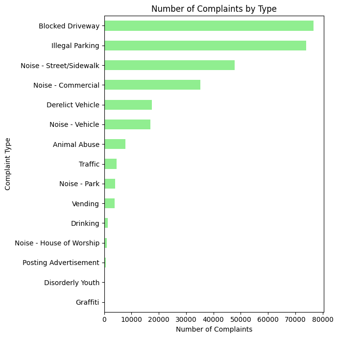

```python
# Create a figure of size 7x7 inches for the plot
plt.figure(figsize=(7, 7))

# Group the DataFrame by 'Complaint Type', count the occurrences, and sort the values
# in ascending order
df1 = df.groupby('Complaint Type').size().sort_values(ascending=True)

# Plot the result as a horizontal bar chart ('barh') with light green color
df1.plot(kind='barh', color='lightgreen', title='Number of Complaints by Type')

# Set the x-axis label (Number of Complaints)
plt.xlabel('Number of Complaints')

# Set the y-axis label (Complaint Type)
plt.ylabel('Complaint Type')

# Adjust the plot layout to ensure everything fits well
plt.tight_layout()

# Show the plot
plt.show()
```

#### Complaint Distribution by Location Type

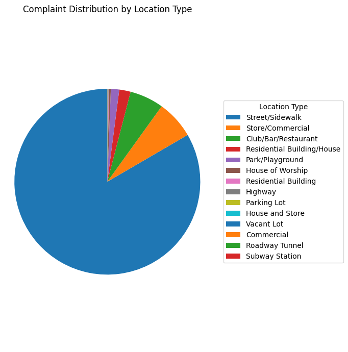

```python
# Get the count of each unique 'Location Type' in the DataFrame
df2 = df['Location Type'].value_counts()

# Create a figure of size 7x7 inches for the plot
plt.figure(figsize=(7, 7))

# Create a pie chart based on the value counts of 'Location Type'
plt.pie(df2, startangle=90)

# Set the title of the pie chart
plt.title('Complaint Distribution by Location Type')

# Make the pie chart circular (equal aspect ratio)
plt.axis('equal')

# Add a legend with location types, and position it outside the pie chart
plt.legend(df2.index, title='Location Type', bbox_to_anchor=(1.05, 0.5), loc='center left')

# Adjust the plot layout to ensure everything fits well
plt.tight_layout()

# Show the plot
plt.show()
```

#### Number of Complaints by Month

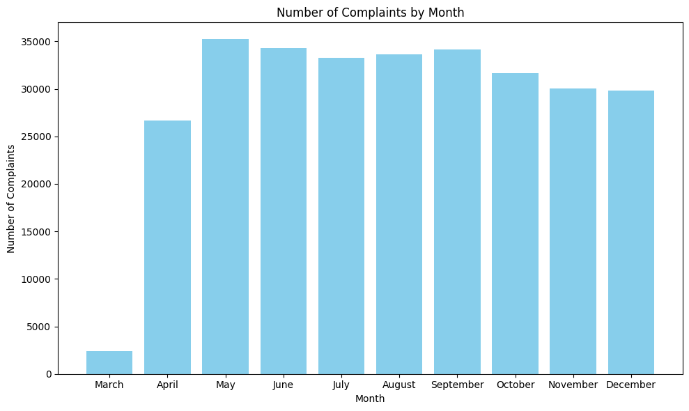

```python
# Extract the month from the 'Created Date' column and create a new 'Month' column in the DataFrame
df['Month'] = df['Created Date'].dt.month

# Count the number of complaints for each month and sort by month (ascending order)
df3 = df['Month'].value_counts().sort_index()

# List of month names corresponding to their numeric representation (1 = January, 12 = December)
month_names = ['January', 'February', 'March', 'April', 'May', 'June',
               'July', 'August', 'September', 'October', 'November', 'December']

# Create a new index with month names instead of numbers
new_index = []
for m in df3.index:
    new_index.append(month_names[m - 1])

# Update the index of the 'df3' Series to the month names
df3.index = new_index

# Create a figure with a size of 10x6 inches
plt.figure(figsize=(10, 6))

# Plot a bar chart showing the number of complaints for each month
plt.bar(df3.index, df3.values, color='skyblue')

# Set the title and labels of the plot
plt.title('Number of Complaints by Month')
plt.xlabel('Month')
plt.ylabel('Number of Complaints')

# Adjust the plot layout to ensure everything fits well
plt.tight_layout()

# Display the plot
plt.show()
```

#### Number of Complaints by the Hour of the Day

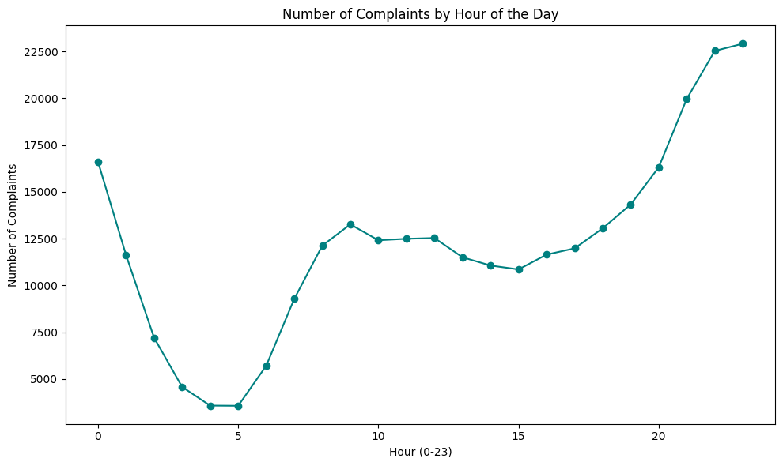

```python
# Extract the hour from the 'Created Date' timestamp and store it in a new 'Hour' column
df['Hour'] = df['Created Date'].dt.hour

# Group the data by hour and count the number of complaints for each hour
df4 = df.groupby('Hour').size()

# Create a new figure with size 10x6 inches
plt.figure(figsize=(10, 6))

# Plot a line graph showing number of complaints per hour
plt.plot(df4.index, df4.values, marker='o', linestyle='-', color='teal')

# Set plot title and axis labels
plt.title('Number of Complaints by Hour of the Day')
plt.xlabel('Hour (0-23)')
plt.ylabel('Number of Complaints')

# Adjust layout to prevent clipping
plt.tight_layout()

# Display the plot
plt.show()
```

#### Average Complaint Closing Time By Location Type

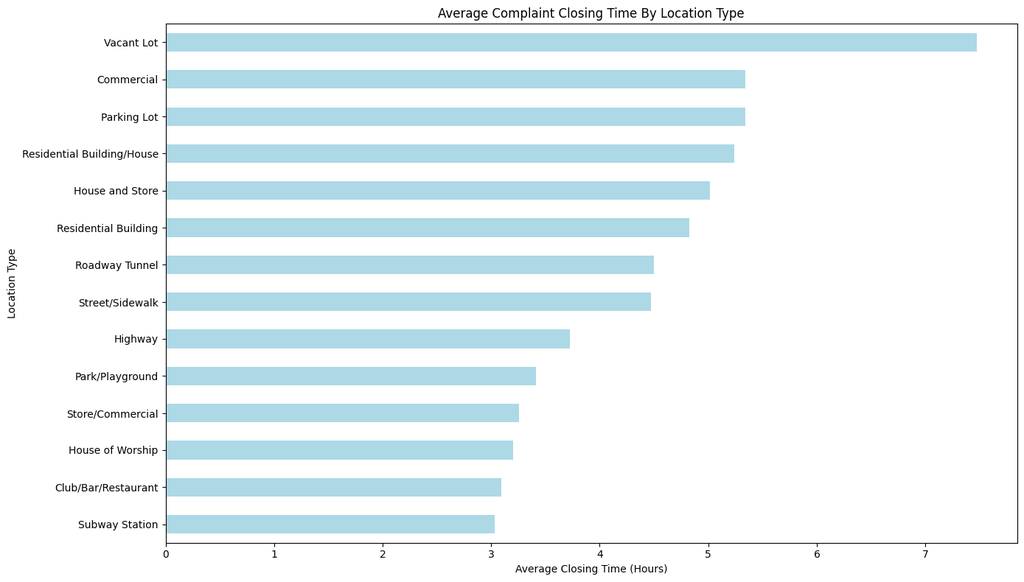

```python
# Calculate the average complaint closing time for each location type
df5 = df.groupby('Location Type')['Request_Closing_Time'].mean().sort_values()

# Create a figure with appropriate size BEFORE plotting
plt.figure(figsize=(14, 8))

# Plot a horizontal bar chart
df5.plot(kind='barh', color='lightblue', title='Average Complaint Closing Time By Location Type')

# Set axis labels
plt.xlabel('Average Closing Time (Hours)')
plt.ylabel('Location Type')

# Adjust layout to prevent clipping
plt.tight_layout()

# Display the plot
plt.show()
```

#### Top 3 Complaint Types By Hour

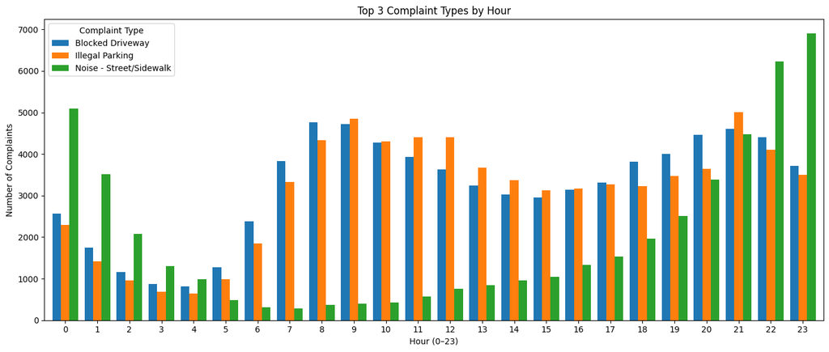

```python
# Step 1: Find the top 3 most frequent complaint types
top3_types = df['Complaint Type'].value_counts().head(3).index

# Step 2: Filter data to include only those top 3 complaint types
#         Then group by hour and complaint type, count occurrences, and unstack for plotting
df6 = df[df['Complaint Type'].isin(top3_types)].groupby(['Hour', 'Complaint Type']).size().unstack()

# Step 3: Plot the grouped data as a bar chart
df6.plot(kind='bar', width=0.8, figsize=(14, 6))

# Step 4: Add labels and formatting
plt.xlabel('Hour (0–23)')
plt.ylabel('Number of Complaints')
plt.title('Top 3 Complaint Types by Hour')
plt.xticks(rotation=0)  # Keep hour labels horizontal
plt.tight_layout()
plt.show()
```

#### Arrange the complaint types according to their average 'Request_Closing_Time', categorized by various locations. Illustrate it through graph as well.

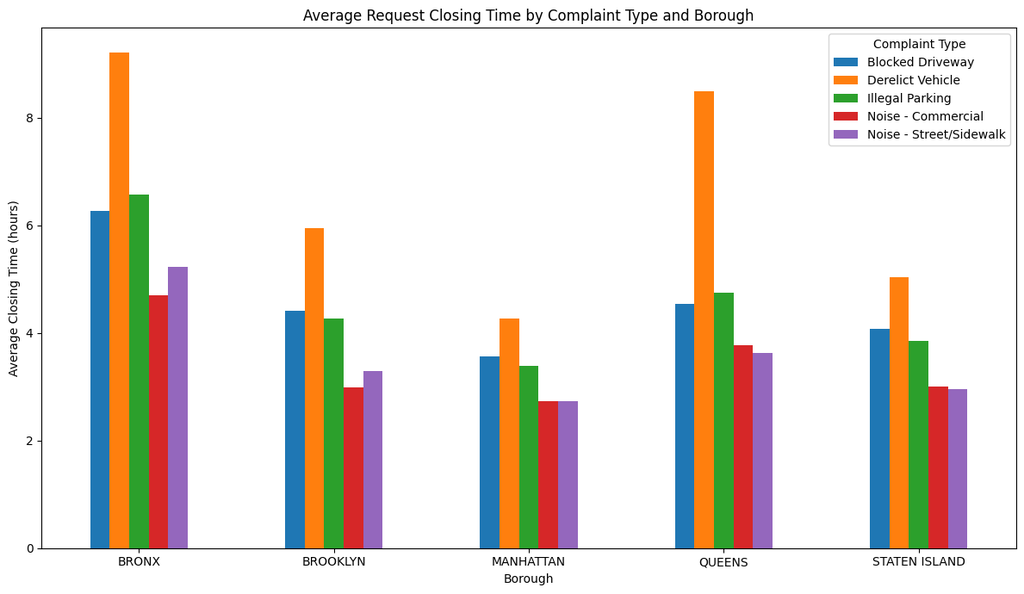

```python
# Step 1: Identify the top 5 most common complaint types
top_complaints = df['Complaint Type'].value_counts().head().index

# Step 2: Filter the DataFrame to include only those top 5 complaints
filtered_df = df[df['Complaint Type'].isin(top_complaints)]

# Step 3: Group by Borough and Complaint Type, then calculate the average closing time
grouped = filtered_df.groupby(['Borough', 'Complaint Type'])['Request_Closing_Time'].mean().unstack()

# Step 4: Plot a grouped bar chart of average closing time by borough and complaint type
grouped.plot(kind='bar', figsize=(12, 7))

# Step 5: Format the plot
plt.title('Average Request Closing Time by Complaint Type and Borough')
plt.xlabel('Borough')
plt.ylabel('Average Closing Time (hours)')
plt.xticks(rotation=0)  # Horizontal x-axis labels
plt.legend(title='Complaint Type')
plt.tight_layout()
plt.show()
```

#### Test 1: Whether the average response time across complaint types is similar or not.

```python
# Importing required function for ANOVA test
from scipy.stats import f_oneway

# Grouping the closing times by complaint type — each group becomes a list of values
grouped_times = df.groupby('Complaint Type')['Request_Closing_Time'].apply(list)

# Performing a one-way ANOVA test on all the grouped lists
f_stat, p_value = f_oneway(*grouped_times)

# Printing F-statistic and P-value to interpret test results
print("F-statistic:", f_stat)
print("P-value:", p_value)

# Interpretation based on significance level (alpha = 0.05)
if p_value < 0.05:
    print("Reject the null hypothesis: There is a significant difference in closing times among complaint types.")
else:
    print("Fail to reject the null hypothesis: No significant difference in closing times among complaint types.")
```

```
F-statistic: 578.9120337398356
P-value: 0.0
Reject the null hypothesis: There is a significant difference in closing times among complaint types.
```

#### Test 2: Whether the type of complaint or service requested, and location are related.

```python
# Importing the chi2_contingency function for the Chi-Square Test
from scipy.stats import chi2_contingency

# Creating a contingency table: rows = Complaint Type, columns = Borough, values = count of records
contingency_table = pd.crosstab(df['Complaint Type'], df['Borough'])

# Performing the Chi-square test on the contingency table
chi2_stat, p_value, dof, expected = chi2_contingency(contingency_table)

# Outputting the test results
print("Chi-square Statistic:", chi2_stat)
print("Degrees of Freedom:", dof)
print("P-value:", p_value)

# Interpreting the p-value using 0.05 as the significance level (alpha)
if p_value < 0.05:
    print("Reject the null hypothesis: Complaint type and borough are dependent (associated).")
else:
    print("Fail to reject the null hypothesis: Complaint type and borough are independent (not associated).")
```

```
Chi-square Statistic: 73264.62164334783
Degrees of Freedom: 56
P-value: 0.0
Reject the null hypothesis: Complaint type and borough are dependent (associated).
```